# Texto 6 – Racismo ambiental e justiça climática

Pablo Castro

2026-06-19

# 1 Introdução

A exposição desigual da população negra a riscos ambientais e a precariedade no acesso a serviços essenciais constituem dimensões centrais do racismo ambiental no Brasil. Este texto, sexto do conjunto de nove análises temáticas previstas no Contrato IC nº 000199/2025-0, integra o Produto 3 e aborda a interface entre desigualdades raciais e vulnerabilidades socioambientais, explorando suas implicações para a justiça climática e políticas territoriais.

Em conformidade com o Plano de Trabalho Geral, a análise utiliza microdados do Censo Demográfico 2022 (IBGE) para examinar a distribuição espacial da população negra em áreas de vulnerabilidade ambiental, o acesso a saneamento básico por raça/cor, e as condições de moradia em favelas e assentamentos precários. A análise é complementada por índices municipais de risco climático (inundações e alagamentos, deslizamento de terra, estresse hídrico e risco ao acesso à energia elétrica), permitindo examinar diretamente a relação entre exposição a eventos climáticos extremos e concentração racial nos territórios. Os resultados evidenciam que a população negra está sobre-representada em territórios com maior precariedade habitacional, menor acesso a serviços essenciais e, como será demonstrado, maior exposição a riscos climáticos, configurando padrões de injustiça ambiental que exigem políticas articuladas de habitação, saneamento, gestão territorial e promoção da igualdade racial.

# 2 O Conceito de Racismo Ambiental e sua Contextualização na Política Brasileira

Antes de apresentar os resultados empíricos, é necessário definir e contextualizar o conceito de racismo ambiental, frequentemente utilizado de forma operacional na literatura brasileira sem maior aprofundamento conceitual.

## 2.1 Origem do Conceito

O termo “racismo ambiental” (*environmental racism*) emerge do movimento por justiça ambiental nos Estados Unidos, nas décadas de 1970 e 1980, a partir da constatação empírica de que populações negras e outras minorias étnicas estavam sistematicamente mais expostas a riscos ambientais — proximidade a aterros sanitários, indústrias poluentes e infraestruturas de risco — do que a população branca, independentemente da renda (Bullard, 2000). O conceito articula, portanto, duas dimensões: (i) a **desigualdade na distribuição espacial dos riscos e danos ambientais**, e (ii) a **desigualdade no acesso aos processos de decisão** sobre políticas e empreendimentos que afetam o território.

No Brasil, o conceito foi incorporado e adaptado por pesquisadores como Herculano e Acselrad, Mello e Bezerra (2009), articulando-se ao conceito mais amplo de **justiça ambiental** (Pacheco, 2011). A institucionalização do debate no país remonta à criação da Rede Brasileira de Justiça Ambiental, em 2001, e à instituição da Comissão Técnica Nacional de Justiça Ambiental pelo Ministério do Meio Ambiente, em 2002, que buscou incorporar a dimensão socioambiental às políticas de proteção a populações vulnerabilizadas, incluindo povos indígenas, comunidades quilombolas e populações negras urbanas.

## 2.2 Racismo Ambiental e o SINAPIR

O Sistema Nacional de Promoção da Igualdade Racial (SINAPIR), instituído pela Lei nº 12.288/2010 (Estatuto da Igualdade Racial), constitui o principal instrumento de articulação federativa das políticas de promoção da igualdade racial no Brasil, mas não contempla, em seu desenho original, um eixo específico voltado à dimensão ambiental e climática das desigualdades raciais. O Estatuto da Igualdade Racial prevê, em seu art. 1º, o direito da população negra à participação na vida econômica, social, política e cultural do país, “tendo em vista os princípios constitucionais da igualdade”, mas a regulamentação e os planos de ação do SINAPIR têm priorizado historicamente os eixos de educação, saúde, trabalho e segurança pública, com menor desenvolvimento da interface entre racismo, território e meio ambiente.

Os resultados apresentados neste texto — particularmente a sobre-representação da população negra em territórios com maior exposição a risco climático (Seção 7) — reforçam a relevância de incorporar explicitamente a dimensão ambiental e climática à atuação do SINAPIR e dos planos plurianuais de promoção da igualdade racial, articulando-a às políticas de habitação, saneamento, gestão de riscos e adaptação climática conduzidas pelo poder público em nível federal, estadual e municipal.

# 3 Composição Racial da População em Favelas

Esta seção analisa a composição racial da população residente em favelas brasileiras, revelando padrões de concentração da população negra nesses territórios marcados por vulnerabilidades socioambientais e precariedade no acesso a serviços essenciais.

## 3.1 Estados com Maior Proporção de População Negra em Favelas

A Figura 3.1 apresenta os dez estados brasileiros com maior proporção de população negra residindo em favelas em 2022. A Bahia lidera com 90,3% de população negra em favelas, seguida pelo Piauí (82,2%) e Mato Grosso (81,4%). Estados do Nordeste e Norte predominam nesse ranking, com Maranhão e Amapá apresentando 80,2% cada, seguidos por Pará (79,9%), Sergipe (79,6%), Tocantins (79,4%), Amazonas (79,2%) e Rondônia (79,0%).

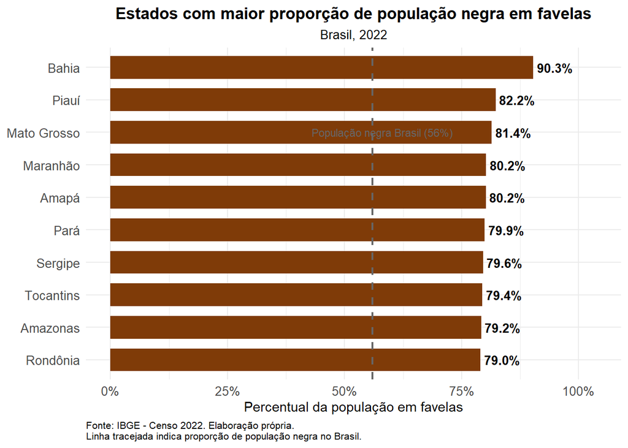

Figure 3.1: Distribuição Racial em Favelas

Todos os dez estados apresentam proporções de população negra em favelas superiores à média nacional (56%), indicada pela linha tracejada no gráfico. Essa concentração regional evidencia a intersecção entre desigualdades raciais e territoriais no acesso à moradia adequada. Estados com maior proporção de população negra no total também apresentam as maiores concentrações desse grupo em assentamentos precários, revelando que o racismo estrutural se manifesta de forma agravada nos territórios mais vulneráveis do país.

## 3.2 População em Unidades de Conservação por Raça/Cor

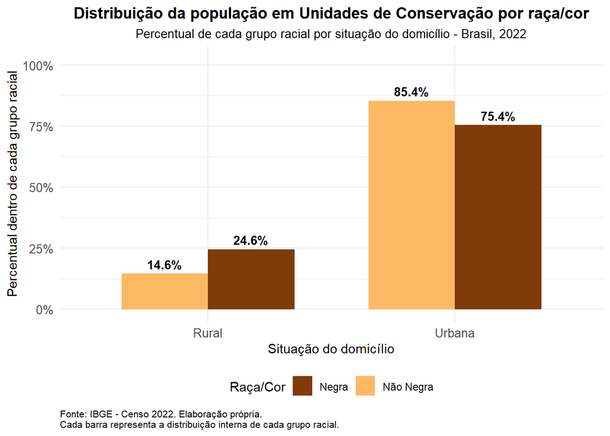

Figure 3.2: População em Unidades de Conservação por Raça/Cor

## 3.3 Sobre-Representação da População Negra em Favelas

A Figura 3.3 compara a composição racial da população em favelas com a população geral brasileira. Enquanto a população negra representa 56% da população total, sua participação sobe para 72,9% entre os moradores de favelas. Inversamente, a população não negra representa 43% da população geral, mas apenas 27,1% dos moradores de favelas.

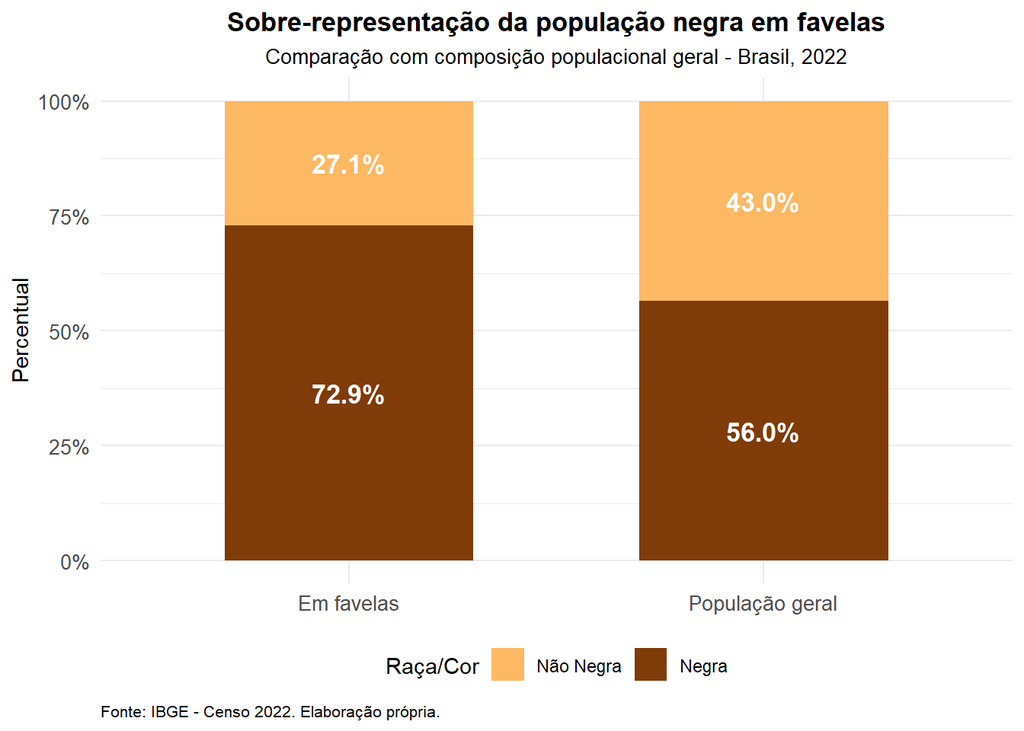

Figure 3.3: Sobre-Representação da População Negra em Favelas

Essa diferença de 16,9 pontos percentuais evidencia segregação residencial de base racial, na qual a população negra tem acesso limitado a moradias adequadas e formais, concentrando-se em territórios marcados por informalidade fundiária, carência de infraestrutura e maior exposição a riscos ambientais.

# 4 Distribuição Territorial da População em Favelas

Esta seção examina a distribuição geográfica da população favelada no Brasil, identificando os estados com maior concentração populacional nesses territórios e a composição racial predominante.

## 4.1 População em Favelas por Unidade da Federação

A Figura 4.1 apresenta a população residente em favelas nos 15 estados com maior contingente populacional nesses assentamentos. São Paulo lidera com 3,6 milhões de pessoas, seguido pelo Rio de Janeiro (2,1 milhões) e Pará (1,5 milhões). Bahia (1,4 milhões), Amazonas (1,4 milhões) e Pernambuco (1,1 milhões) completam o grupo de estados com mais de 1 milhão de habitantes em favelas.

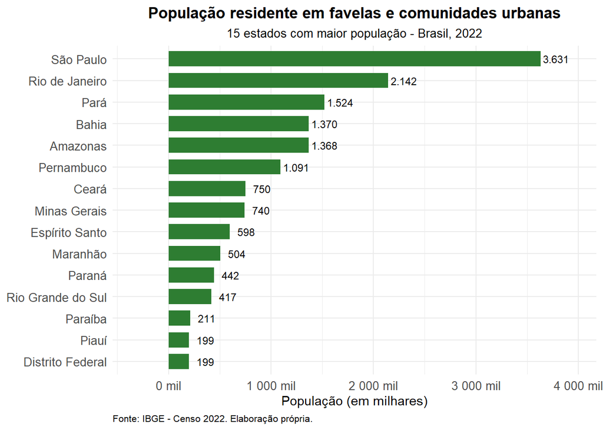

Figure 4.1: População em Favelas por Unidade da Federação

Essa distribuição reflete tanto a concentração populacional geral desses estados quanto processos históricos de urbanização desigual, nos quais o crescimento acelerado das cidades não foi acompanhado de políticas habitacionais capazes de atender as populações de baixa renda, especialmente negras.

# 5 Desigualdades Raciais no Acesso a Saneamento Básico

Esta seção analisa as desigualdades raciais no acesso a serviços de saneamento básico, especialmente abastecimento de água e esgotamento sanitário, revelando como a população negra enfrenta déficits significativos nesses serviços essenciais.

## 5.1 Acesso à Rede de Água por Raça/Cor

A Figura 5.1 apresenta as taxas de acesso à rede geral de água utilizada por raça/cor. A população não negra apresenta taxa de acesso de 87,5%, enquanto a população negra tem acesso ligeiramente inferior, de 85,0%.

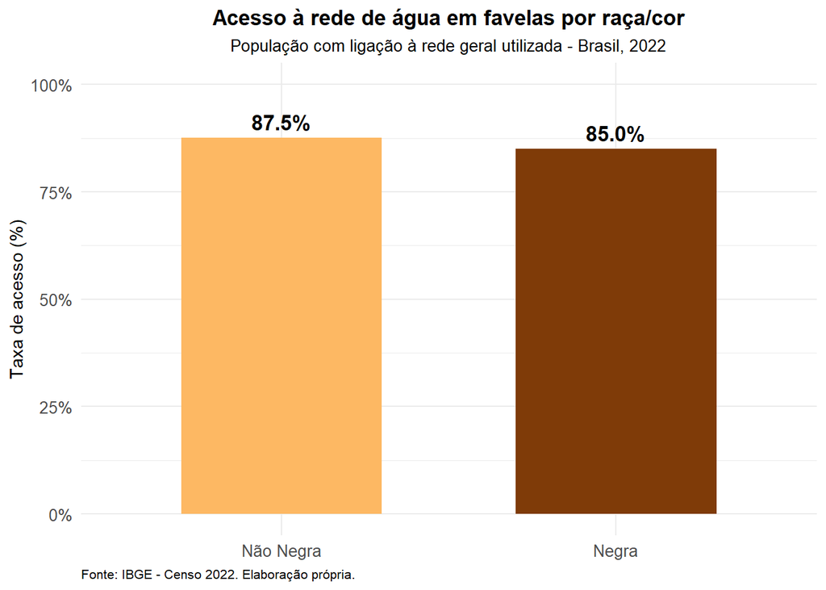

Figure 5.1: Acesso à Rede de Água por Raça/Cor

Embora a diferença de 2,5 pontos percentuais possa parecer pequena, ela representa cerca de 2,8 milhões de pessoas negras a mais sem acesso adequado à água. Essa desigualdade reflete padrões estruturais de racismo ambiental, nos quais a população negra tem menor acesso a serviços essenciais devido à sua concentração em territórios periféricos e informais.

## 5.2 Desigualdade Racial no Acesso à Água por Estado

A Figura 5.2 apresenta o gap (diferença) de acesso à água entre população não negra e negra nas dez unidades da federação com maiores disparidades. Em oito estados, a população não negra tem maior acesso à água do que a população negra, enquanto em dois estados (Rio Grande do Sul e Mato Grosso do Sul) a população negra tem vantagem.

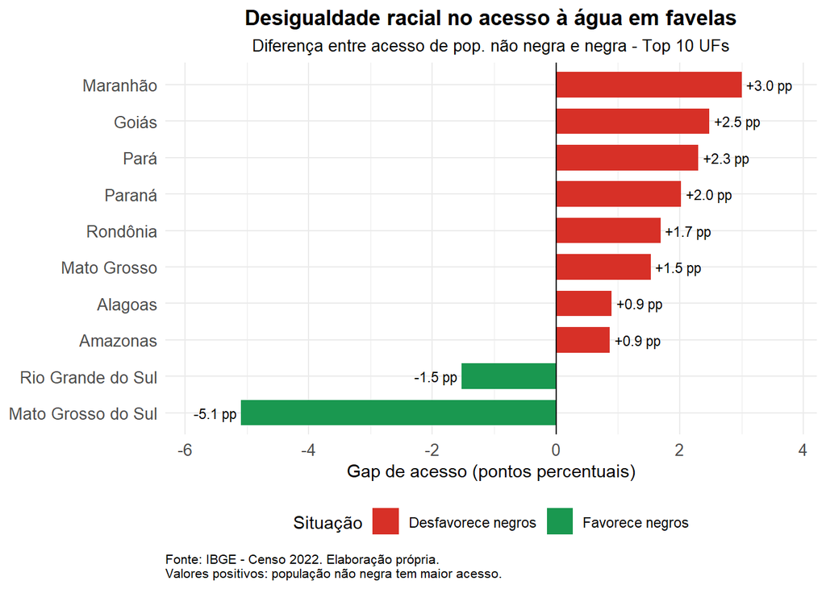

Figure 5.2: Desigualdade Racial no Acesso à Água por Estado

O Maranhão apresenta o maior gap favorável à população não negra (+3,0 pontos percentuais), seguido por Goiás (+2,5 pp), Pará (+2,3 pp) e Paraná (+2,0 pp). Mato Grosso do Sul apresenta a maior vantagem para a população negra (-5,1 pp), seguido pelo Rio Grande do Sul (-1,5 pp). Essas disparidades regionais evidenciam que o racismo ambiental opera de forma diferenciada nos territórios, exigindo políticas específicas em cada contexto.

## 5.3 Detalhamento do Acesso à Água em Favelas

A Figura 5.3 apresenta a composição detalhada do acesso à água em favelas por raça/cor, distinguindo entre acesso pleno, ligação parcial e sem acesso. Entre a população não negra, 87,5% têm acesso pleno à rede de água, 2,9% têm ligação parcial e 9,5% não têm acesso. Entre a população negra, 85,0% têm acesso pleno, 3,2% têm ligação parcial e 11,8% não têm acesso.

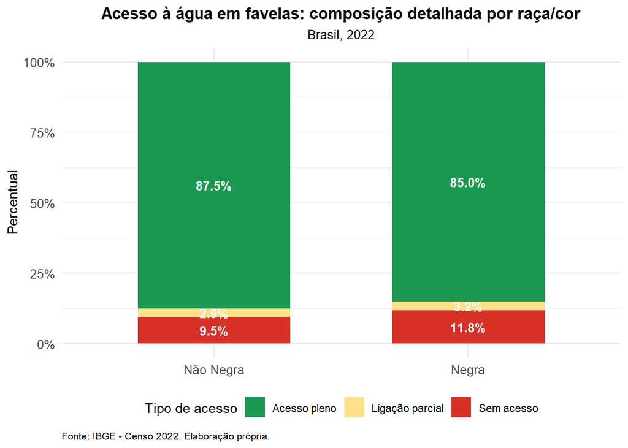

Figure 5.3: Detalhamento do Acesso à Água em Favelas

A maior proporção de população negra sem acesso à água (11,8% versus 9,5%) representa cerca de 1,7 milhões de pessoas negras em situação de vulnerabilidade extrema, sem direito básico à água potável. Essa desigualdade se agrava em contextos de eventos climáticos extremos, quando a falta de acesso à água compromete a saúde e a dignidade dessas populações.

# 6 Esgotamento Sanitário em Favelas

Esta seção examina as condições de esgotamento sanitário em favelas brasileiras, revelando a precariedade dos sistemas de coleta e tratamento de esgoto nesses territórios.

## 6.1 Tipo de Esgotamento Sanitário em Favelas

A Figura 6.1 apresenta a distribuição dos tipos de esgotamento sanitário nas favelas brasileiras. A rede geral de esgoto atende 59,4% da população favelada, enquanto 13,9% utilizam fossa séptica, 13,6% fossa rudimentar e 13,1% outros tipos de solução.

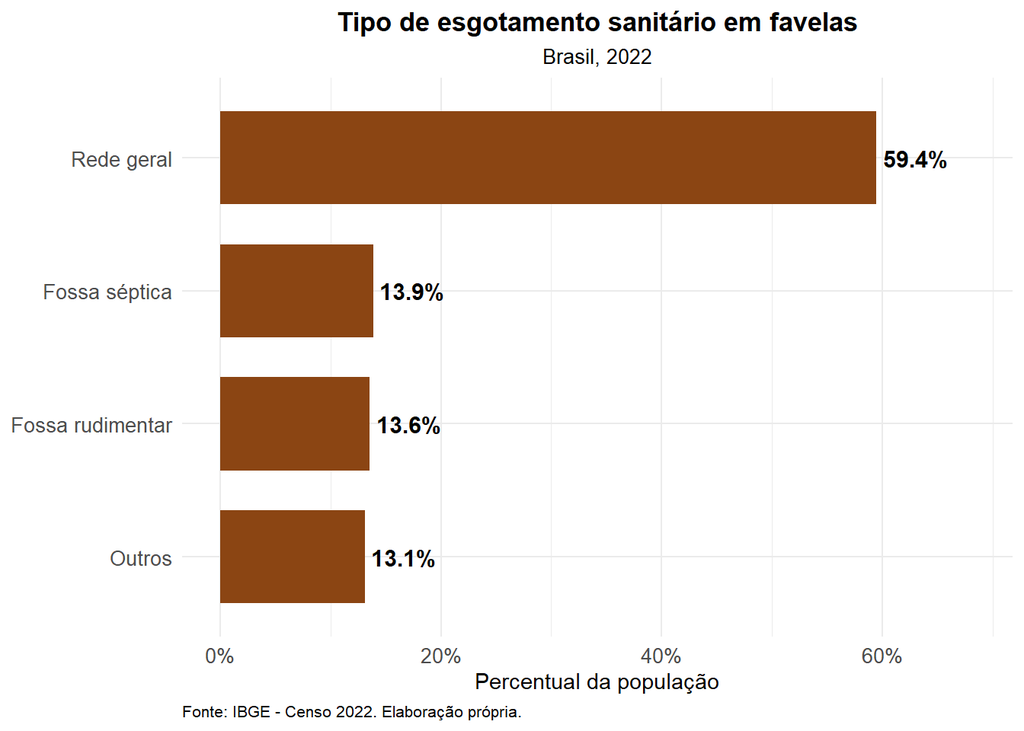

Figure 6.1: Tipo de Esgotamento Sanitário em Favelas

Esses dados revelam que 40,6% da população em favelas não têm acesso à rede geral de esgoto, dependendo de soluções precárias ou inadequadas. A ausência de esgotamento adequado expõe essas populações a doenças de veiculação hídrica, contaminação ambiental e condições de vida degradantes, violando direitos humanos fundamentais.

## 6.2 Composição Racial Detalhada em Favelas

A Figura 6.2 apresenta a composição racial detalhada da população em favelas, desagregando as categorias raciais. A população parda representa 56,8%, seguida pela branca (26,6%), preta (16,1%), indígena (0,3%) e amarela (0,1%).

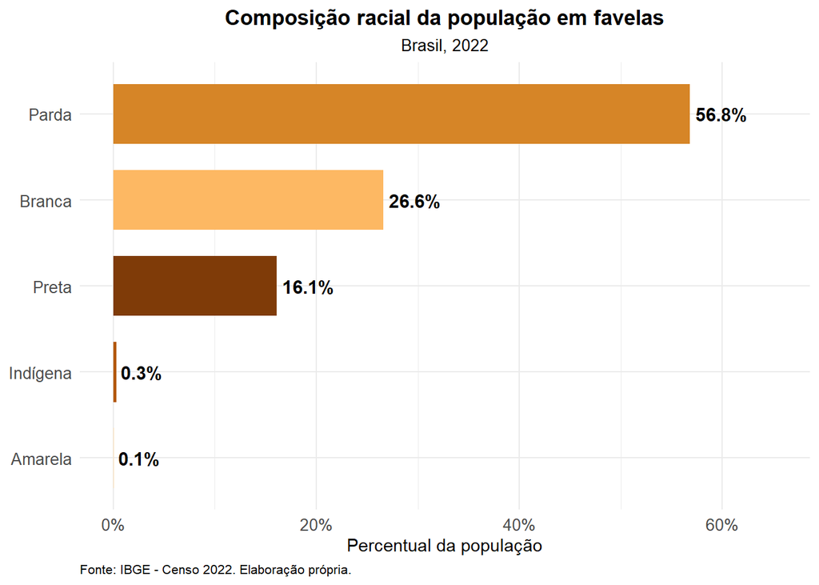

Figure 6.2: Composição Racial Detalhada em Favelas

A concentração de 72,9% de população negra (pardos e pretos) em favelas, onde apenas 59,4% têm acesso à rede de esgoto, configura situação de racismo ambiental estrutural. Essa população enfrenta simultaneamente precariedade habitacional, déficit de saneamento e maior exposição a riscos ambientais, evidenciando a necessidade de políticas de justiça climática que priorizem esses territórios.

# 7 Risco Climático e sua Distribuição Territorial

As seções anteriores documentaram a precariedade habitacional e de saneamento da população negra em favelas, mas não examinaram diretamente indicadores de risco climático. Esta seção incorpora índices municipais de risco climático — inundações, enxurradas e alagamentos; deslizamento de terra; estresse hídrico; e risco ao acesso à energia elétrica — para avaliar se os territórios mais expostos a esses riscos coincidem com os territórios de maior concentração racial negra identificados nas seções anteriores.

## 7.1 Distribuição Regional do Risco Climático

A Figura 7.1 apresenta o percentual de municípios classificados em risco “Alto” ou “Muito Alto” para cada um dos quatro indicadores, segundo a região do país.

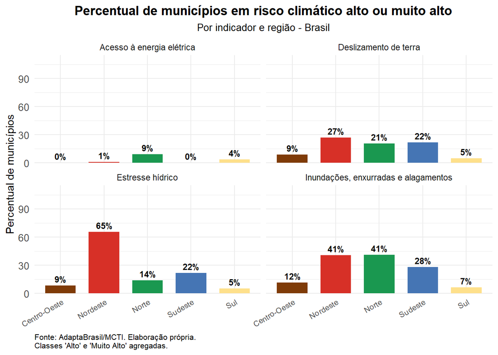

Figure 7.1: Percentual de Municípios em Risco Climático Alto ou Muito Alto, por Região

A distribuição regional do risco climático não é homogênea: o Nordeste concentra a maior proporção de municípios em risco alto ou muito alto para inundações/alagamentos e estresse hídrico, enquanto o Norte se destaca no risco de acesso à energia elétrica. Essas são justamente as regiões que, nas seções anteriores, apresentaram a maior concentração de população negra em favelas (acima de 79% em estados como Maranhão, Amapá e Pará).

## 7.2 Risco Climático e Concentração Racial em Favelas, por Estado

Para examinar diretamente essa associação, o Figura 7.2 cruza, para cada Unidade da Federação, o percentual de municípios em risco alto ou muito alto (eixo vertical) com o percentual de população negra entre os moradores de favelas (eixo horizontal, já apresentado na Seção 3).

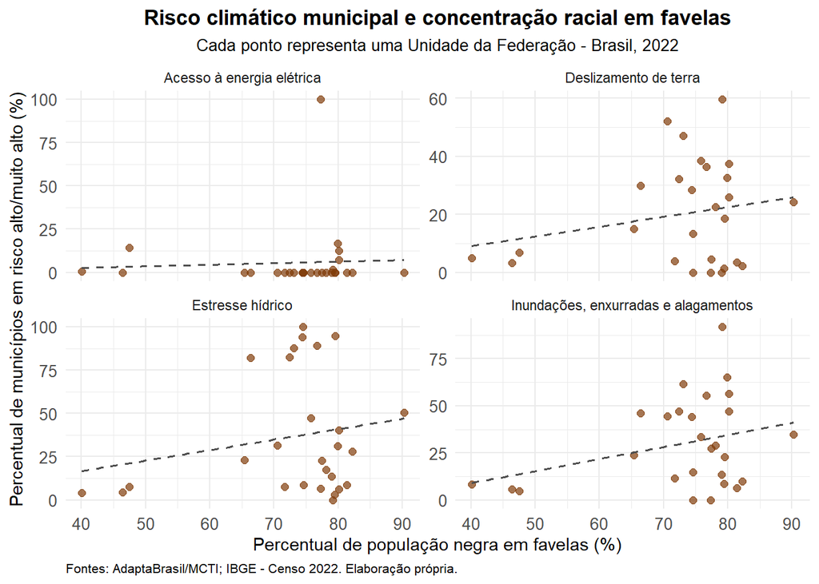

Figure 7.2: Risco Climático Municipal e Concentração Racial em Favelas, por UF

É importante notar que essa é uma análise ao nível agregado de UF (ecológica), e não uma medida direta da exposição individual de pessoas negras a esses riscos; municípios são unidades heterogêneas internamente, e a análise não permite afirmar que são especificamente os bairros/territórios de maioria negra dentro de cada município os mais expostos. Ainda assim, a convergência territorial entre risco climático e concentração racial em favelas é consistente com o arcabouço conceitual de racismo ambiental apresentado na Seção 2, e reforça a necessidade de dados de risco climático desagregados por território intramunicipal e raça/cor para uma mensuração mais precisa.

# 8 Considerações sobre Racismo Ambiental e Justiça Climática

Os dados analisados neste texto evidenciam a existência de racismo ambiental estrutural no Brasil, manifestado pela concentração desproporcional da população negra em territórios com maior vulnerabilidade socioambiental e menor acesso a serviços essenciais. A população negra representa 72,9% dos moradores de favelas, percentual muito superior à sua proporção populacional (56%), configurando segregação residencial de base racial.

As desigualdades no acesso a saneamento básico agravam esse quadro. Embora a diferença no acesso à água entre população negra (85,0%) e não negra (87,5%) pareça pequena, ela representa milhões de pessoas negras sem direito básico à água potável. Essa desigualdade varia regionalmente, com estados como Maranhão, Goiás e Pará apresentando gaps superiores a 2 pontos percentuais.

A precariedade do esgotamento sanitário em favelas, onde 40,6% da população não tem acesso à rede geral, afeta desproporcionalmente a população negra devido à sua concentração nesses territórios. Essa situação viola direitos humanos fundamentais e expõe essas comunidades a doenças, contaminação ambiental e condições de vida degradantes.

A distribuição territorial da população favelada evidencia concentração em grandes centros urbanos, com São Paulo (3,6 milhões) e Rio de Janeiro (2,1 milhões) liderando, mas também presença significativa em estados do Norte e Nordeste. Estados como Bahia, Piauí e Maranhão apresentam mais de 80% de população negra em favelas, evidenciando padrões regionais de exclusão territorial.

Como discutido na Seção 2, o conceito de racismo ambiental tem origem no movimento norte-americano por justiça ambiental e foi incorporado à literatura e à institucionalidade brasileira a partir dos anos 2000, mas ainda carece de articulação mais explícita com o Sistema Nacional de Promoção da Igualdade Racial (SINAPIR). Os resultados aqui apresentados — habitacionais, de saneamento e, agora, de risco climático — fornecem subsídios concretos para que essa articulação seja fortalecida nos próximos planos de ação do SINAPIR e nas políticas de adaptação climática em todas as esferas de governo.

Esses resultados reforçam a necessidade de políticas de justiça climática que reconheçam a dimensão racial das vulnerabilidades socioambientais. É fundamental garantir acesso universal ao saneamento básico, regularização fundiária em favelas, investimentos em infraestrutura urbana e em gestão de risco climático em territórios periféricos, participação das comunidades negras na elaboração de políticas ambientais e habitacionais, e a incorporação explícita da dimensão ambiental e climática ao SINAPIR. Apenas com ações coordenadas e antirracistas será possível superar o racismo ambiental e construir cidades mais justas, seguras e sustentáveis frente às mudanças climáticas.

## Referências

ADAPTABRASIL/MCTI. **Índices municipais de risco climático**. Ministério da Ciência, Tecnologia e Inovação. Disponível em: adaptabrasil.mcti.gov.br.

BRASIL. **Lei nº 12.288, de 20 de julho de 2010**. Institui o Estatuto da Igualdade Racial e o Sistema Nacional de Promoção da Igualdade Racial (SINAPIR). Brasília: Diário Oficial da União, 2010.

BRASIL. **Lei nº 14.026, de 15 de julho de 2020**. Atualiza o marco legal do saneamento básico. Brasília: Diário Oficial da União, 2020.

IBGE. **Censo Demográfico 2022**. Rio de Janeiro: IBGE, 2023.

IBGE. **Aglomerados Subnormais 2022: classificação preliminar e informações de saúde para o enfrentamento à COVID-19**. Rio de Janeiro: IBGE, 2020.

ACSELRAD, Henri; MELLO, Cecília Campello do Amaral; BEZERRA, Gustavo das Neves. **O que é justiça ambiental**. Rio de Janeiro: Garamond, 2009.

BULLARD, Robert D. **Dumping in Dixie: Race, Class, and Environmental Quality**. Boulder: Westview Press, 2000.

HERCULANO, Selene. **Racismo ambiental, o que é isso?** Disponível em diversos periódicos acadêmicos sobre justiça ambiental.

PACHECO, Tania. **Desigualdade, injustiça ambiental e racismo: uma luta que transcende a cor da pele**. Proposta, v. 35, n. 128, 2011.